# Global Energy Consumption: To show future fossil fuel consumption based on economic, demographic, and energy production factors across different continents.

# 1. Domain-specific area and objectives of the project

The focus of this project is on global energy consumption, a pivotal topic in the realm of environmental science and policy-making. By employing linear regression, we aim to unravel the intricate relationship between various socio-economic and environmental factors and the energy consumption patterns of different countries. This approach will provide insights into how different factors influence energy usage globally

Objectives:

Selecting an appropriate dataset encompassing worldwide energy consumption and relevant influencing factors. Preprocess the dataset to ensure cleanliness and suitability for modeling and visualization. Develop a predictive model to estimate energy consumption based on various global factors. The significance of this project lies in its potential to inform policy decisions and contribute to a sustainable future by understanding energy consumption patterns. It also adds to the broader conversation about using data science in environmental analysis.

# 2,Dataset description

The dataset chosen is the "World Energy Consumption" dataset, sourced from Kaggle. The dataset's comprehensive nature, covering a wide range of variables and spanning numerous years, makes it an ideal candidate for in-depth analysis. It allows for the exploration of trends over time, the impact of different energy sources on total consumption, and the correlation between energy usage and socio-economic factors like population and GDP.The dataset includes 22,012 entries with 129 features, encompassing both categorical and numerical data types, such as country, year, population, GDP, and various metrics on energy consumption (e.g., biofuel, coal, renewable sources).

Variables include:

- Diverse Data Types: The dataset is a blend of categorical and numerical data types, offering a holistic view of global energy consumption.
- Categorical: Country, Energy Source Types
- Numerical: Population, GDP, Energy Consumption by Source
- Target Variable: Total Energy Consumption (continuous)

The dataset's source is available on Kaggle: World Energy Consumption. This dataset's richness and diversity make it an ideal candidate for exploring global energy consumption trends and the influence of socio-economic factors.

# 3. Data preparation (acquisition/cleaning/sanitisation/normalisation)

The dataset is in CSV format and to perform operations on it we will load the it to a dataframe

The issues with the dataset and its solutions are as follows:

Categorical Data Normalization: String values in the 'country' column are formatted to title case for consistency.

First Normal Form (1NF) Compliance: The dataset is verified to ensure it adheres to 1NF, where each column represents a single attribute, and each row represents a single entity.

Saving the Processed Data: The cleaned DataFrame is saved back to a CSV file, making it ready for analysis.

```python
import pandas as pd
import numpy as np
from google.colab import drive

# Mount Google Drive
drive.mount('/content/drive')

# Access the file from Google Drive and load it
file_path = '/content/drive/MyDrive/World Energy Consumption.csv'
df = pd.read_csv(file_path)

# Define a function to clean text and handle empty strings or null values
def clean_text(text):
    if pd.isna(text):
        return np.nan  # Return np.nan for NaN values
    else:
        text = " ".join(str(text).strip().split())
        return text.title()  # Convert text to title case for consistency

# Apply the clean_text function to all string columns
string_cols = df.select_dtypes(include=['object']).columns
df[string_cols] = df[string_cols].applymap(clean_text)

# Create a boolean column to track filled GDP values before filling missing values
df['gdp_filled'] = df['gdp'].isna()

# Impute missing values with appropriate statistics
for col in df.select_dtypes(include=[np.number]).columns:
    if df[col].isna().sum() > 0:
        if col == 'gdp':
            df[col].fillna(df[col].median(), inplace=True)
        else:
            df[col].fillna(df[col].mean(), inplace=True)

# Save the cleaned data with UTF-8 encoding
cleaned_file_path = '/content/cleaned_world_energy_consumption.csv'
df.to_csv(cleaned_file_path, index=False, encoding='utf-8')

# Reload the saved data, ensuring the 'year' column is treated as a string
df_reloaded = pd.read_csv(cleaned_file_path, dtype={'year': str}, encoding='utf-8')

print("First few rows of reloaded data:")
print(df_reloaded.head())

print(f"Data cleaned and saved as {cleaned_file_path}")
```

```
First few rows of reloaded data:
         country  year iso_code    population           gdp  \
0  Asean (Ember)  2000      NaN  1.053096e+08  4.167411e+10
1  Asean (Ember)  2001      NaN  1.053096e+08  4.167411e+10
2  Asean (Ember)  2002      NaN  1.053096e+08  4.167411e+10
3  Asean (Ember)  2003      NaN  1.053096e+08  4.167411e+10
4  Asean (Ember)  2004      NaN  1.053096e+08  4.167411e+10

   biofuel_cons_change_pct  biofuel_cons_change_twh  biofuel_cons_per_capita  \
0                46.091694                 2.719074               133.558459
1                46.091694                 2.719074               133.558459
2                46.091694                 2.719074               133.558459
3                46.091694                 2.719074               133.558459
4                46.091694                 2.719074               133.558459

   biofuel_consumption  biofuel_elec_per_capita  ...  solar_share_energy  \
0            38.068209                  64.7168  ...            0.210395
1            38.068209                  64.7168  ...            0.210395
2            38.068209                  64.7168  ...            0.210395
3            38.068209                  64.7168  ...            0.210395
4            38.068209                  64.7168  ...            0.210395

   wind_cons_change_pct  wind_cons_change_twh  wind_consumption  \
0            267.541206              7.314174         53.422938
1            267.541206              7.314174         53.422938
2            267.541206              7.314174         53.422938
3            267.541206              7.314174         53.422938
4            267.541206              7.314174         53.422938

   wind_elec_per_capita  wind_electricity  wind_energy_per_capita  \
0             62.811828               0.0              232.108949
1             62.811828               0.0              232.108949
2             62.811828               0.0              232.108949
3             62.811828               0.0              232.108949
4             62.811828               0.0              232.108949

   wind_share_elec  wind_share_energy  gdp_filled
0              0.0           0.651413        True
1              0.0           0.651413        True
2              0.0           0.651413        True
3              0.0           0.651413        True
4              0.0           0.651413        True

[5 rows x 130 columns]
Data cleaned and saved as /content/cleaned_world_energy_consumption.csv
```

```python
df.head(100)
```

|  | country | year | iso_code | population | gdp | biofuel_cons_change_pct | biofuel_cons_change_twh | biofuel_cons_per_capita | biofuel_consumption | biofuel_elec_per_capita | ... | solar_share_energy | wind_cons_change_pct | wind_cons_change_twh | wind_consumption | wind_elec_per_capita | wind_electricity | wind_energy_per_capita | wind_share_elec | wind_share_energy | gdp_filled |
| --- | --- | --- | --- | --- | --- | --- | --- | --- | --- | --- | --- | --- | --- | --- | --- | --- | --- | --- | --- | --- | --- |
| 0 | Asean (Ember) | 2000 | NaN | 1.053096e+08 | 4.167411e+10 | 46.091694 | 2.719074 | 133.558459 | 38.068209 | 64.7168 | ... | 0.210395 | 267.541206 | 7.314174 | 53.422938 | 62.811828 | 0.000000 | 232.108949 | 0.00000 | 0.651413 | True |
| 1 | Asean (Ember) | 2001 | NaN | 1.053096e+08 | 4.167411e+10 | 46.091694 | 2.719074 | 133.558459 | 38.068209 | 64.7168 | ... | 0.210395 | 267.541206 | 7.314174 | 53.422938 | 62.811828 | 0.000000 | 232.108949 | 0.00000 | 0.651413 | True |
| 2 | Asean (Ember) | 2002 | NaN | 1.053096e+08 | 4.167411e+10 | 46.091694 | 2.719074 | 133.558459 | 38.068209 | 64.7168 | ... | 0.210395 | 267.541206 | 7.314174 | 53.422938 | 62.811828 | 0.000000 | 232.108949 | 0.00000 | 0.651413 | True |
| 3 | Asean (Ember) | 2003 | NaN | 1.053096e+08 | 4.167411e+10 | 46.091694 | 2.719074 | 133.558459 | 38.068209 | 64.7168 | ... | 0.210395 | 267.541206 | 7.314174 | 53.422938 | 62.811828 | 0.000000 | 232.108949 | 0.00000 | 0.651413 | True |
| 4 | Asean (Ember) | 2004 | NaN | 1.053096e+08 | 4.167411e+10 | 46.091694 | 2.719074 | 133.558459 | 38.068209 | 64.7168 | ... | 0.210395 | 267.541206 | 7.314174 | 53.422938 | 62.811828 | 0.000000 | 232.108949 | 0.00000 | 0.651413 | True |
| ... | ... | ... | ... | ... | ... | ... | ... | ... | ... | ... | ... | ... | ... | ... | ... | ... | ... | ... | ... | ... | ... |
| 95 | Afghanistan | 1972 | Afg | 1.128675e+07 | 1.317055e+10 | 46.091694 | 2.719074 | 133.558459 | 38.068209 | 64.7168 | ... | 0.210395 | 267.541206 | 7.314174 | 53.422938 | 62.811828 | 17.561153 | 232.108949 | 1.40491 | 0.651413 | False |
| 96 | Afghanistan | 1973 | Afg | 1.157531e+07 | 1.356863e+10 | 46.091694 | 2.719074 | 133.558459 | 38.068209 | 64.7168 | ... | 0.210395 | 267.541206 | 7.314174 | 53.422938 | 62.811828 | 17.561153 | 232.108949 | 1.40491 | 0.651413 | False |
| 97 | Afghanistan | 1974 | Afg | 1.186988e+07 | 1.430911e+10 | 46.091694 | 2.719074 | 133.558459 | 38.068209 | 64.7168 | ... | 0.210395 | 267.541206 | 7.314174 | 53.422938 | 62.811828 | 17.561153 | 232.108949 | 1.40491 | 0.651413 | False |
| 98 | Afghanistan | 1975 | Afg | 1.215739e+07 | 1.517777e+10 | 46.091694 | 2.719074 | 133.558459 | 38.068209 | 64.7168 | ... | 0.210395 | 267.541206 | 7.314174 | 53.422938 | 62.811828 | 17.561153 | 232.108949 | 1.40491 | 0.651413 | False |
| 99 | Afghanistan | 1976 | Afg | 1.242528e+07 | 1.602361e+10 | 46.091694 | 2.719074 | 133.558459 | 38.068209 | 64.7168 | ... | 0.210395 | 267.541206 | 7.314174 | 53.422938 | 62.811828 | 17.561153 | 232.108949 | 1.40491 | 0.651413 | False |

100 rows × 130 columns

# 4.Statistical Analysis

We will now performa a satistical analuysis of this dataset.

```python
import pandas as pd
from scipy.stats import describe
```

We will now load the cleaned dataset from before.

```python
df = pd.read_csv('cleaned_world_energy_consumption.csv')
```

# 4.1 Statistical Summary of Numerical Variables:

The "World Energy Consumption" dataset contains a wealth of numerical data that offers insights into global energy patterns. By examining the descriptive statistics, we observe significant variations in energy metrics that can be associated with diverse economic development levels and energy policies across regions. The central tendency measures, such as mean and median, reveal the average scale of energy consumption, while the spread, including standard deviation and IQR, indicates the disparity among countries.

```python
print(df.describe())
```

```
               year    population           gdp  biofuel_cons_change_pct  \
count  22012.000000  2.201200e+04  2.201200e+04             22012.000000
mean    1974.213247  1.053096e+08  2.016329e+11                46.091694
std       35.058653  4.210603e+08  1.720499e+12                77.344467
min     1900.000000  1.833000e+03  1.642060e+08              -100.000000
25%     1946.000000  2.749202e+06  4.100318e+10                46.091694
50%     1984.000000  1.066238e+07  4.167411e+10                46.091694
75%     2003.000000  1.053096e+08  4.258133e+10                46.091694
max     2022.000000  7.975105e+09  1.136302e+14              5659.328000

       biofuel_cons_change_twh  biofuel_cons_per_capita  biofuel_consumption  \
count             22012.000000             22012.000000         22012.000000
mean                  2.719074               133.558459            38.068209
std                   3.513196                85.586496            39.569491
min                 -50.843000                 0.000000             0.000000
25%                   2.719074               133.558459            38.068209
50%                   2.719074               133.558459            38.068209
75%                   2.719074               133.558459            38.068209
max                 141.131000              2588.512000          1199.207000

       biofuel_elec_per_capita  biofuel_electricity  biofuel_share_elec  ...  \
count             22012.000000         22012.000000        22012.000000  ...
mean                 64.716800            10.966685            1.954035  ...
std                  98.410425            24.027380            2.634261  ...
min                   0.000000             0.000000            0.000000  ...
25%                  64.716800            10.966685            1.954035  ...
50%                  64.716800            10.966685            1.954035  ...
75%                  64.716800            10.966685            1.954035  ...
max                2514.102000           677.570000           71.429000  ...

       solar_share_elec  solar_share_energy  wind_cons_change_pct  \
count      22012.000000        22012.000000          22012.000000
mean           0.622750            0.210395            267.541206
std            1.152474            0.275400           1966.637121
min            0.000000            0.000000           -100.000000
25%            0.306000            0.210395            267.541206
50%            0.622750            0.210395            267.541206
75%            0.622750            0.210395            267.541206
max           40.000000            7.586000         242384.844000

```

[output cut: 16 more lines]

```
50%           17.561153              232.108949         1.404910
75%           17.561153              232.108949         1.404910
max         2139.230000             8422.012000        56.840000

       wind_share_energy
count       22012.000000
mean            0.651413
std             0.817355
min             0.000000
25%             0.651413
50%             0.651413
75%             0.651413
max            26.157000

[8 rows x 127 columns]
```

# 4.2 Statistical Summary of Categorical Variables:

The categorical data, although less prominent in this dataset, play a critical role in providing context. For example, categorizing data by 'country' or 'iso_code' allows us to delve into the geographical nuances of energy use, revealing how regional factors influence consumption and production patterns.

# 4.3 Type of Distribution of Key Series:

In analyzing key numerical series such as GDP or specific energy metrics, understanding their distribution is crucial. Visualizing these distributions through histograms enables us to identify patterns, such as skewness, and understand the range and concentration of values, providing a foundational understanding for further analysis and modeling.

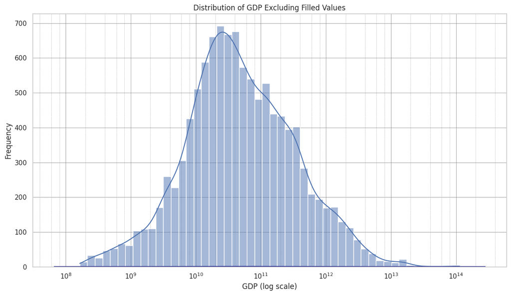

```python
import pandas as pd
import matplotlib.pyplot as plt
import seaborn as sns
from scipy.stats import skew, kurtosis

# Assuming df_energy is your DataFrame after cleaning
# Re-load the cleaned dataset if needed
df= pd.read_csv('/content/cleaned_world_energy_consumption.csv')

# Set the style for the seaborn plots
sns.set(style="whitegrid")

# Define numeric columns, excluding 'year' and 'gdp_filled' which are not relevant for statistical analysis
# Assuming that 'year' is already converted to integer, we don't need to exclude it here
numeric_cols = df.select_dtypes(include=[np.number]).columns

# Calculate measures of central tendency for numeric columns
central_tendency = df[numeric_cols].agg(['mean', 'median'])

# Calculate measures of spread for numeric columns
spread = df[numeric_cols].agg(['std', 'min', 'max'])
spread.loc['IQR'] = df[numeric_cols].quantile(0.75) - df[numeric_cols].quantile(0.25)

# Calculate the type of distribution for numeric columns
distribution_type = pd.DataFrame({
    'Skewness': df[numeric_cols].apply(skew),
    'Kurtosis': df[numeric_cols].apply(kurtosis)
})


# Plot the histogram for 'gdp' excluding the filled values
plt.figure(figsize=(12, 7))
sns.histplot(df[df['gdp_filled'] == False]['gdp'], bins=50, kde=True, log_scale=True)

# Overlay the KDE plot
sns.kdeplot(df[df['gdp_filled'] == False]['gdp'], color='navy', lw=2)


# Get the current axis of the plot and set the grid
ax = plt.gca()
ax.grid(True, which='major', linestyle='-', linewidth='0.5', color='grey')
ax.grid(True, which='minor', linestyle=':', linewidth='0.5', color='grey')

# Set major and minor ticks to improve grid appearance
ax.xaxis.set_major_locator(plt.LogLocator(base=10.0, numticks=15))
ax.xaxis.set_minor_locator(plt.LogLocator(base=10.0, subs=(0.2, 0.4, 0.6, 0.8), numticks=15))



#set labels for better readbility
plt.title('Distribution of GDP Excluding Filled Values')
plt.xlabel('GDP (log scale)')
plt.ylabel('Frequency')


plt.tight_layout()
plt.show()
```

The analysis of GDP distribution reveals a right-skewed pattern, common in economic datasets, where a majority of values cluster at the lower end, suggesting that most countries have modest GDPs. In contrast, a minority exhibit significantly higher GDPs, indicative of economic inequality. The long tail towards the higher end highlights the outliers. Such distributions necessitate careful consideration in modeling, possibly requiring data transformation to achieve more accurate and representative models.

# #5. Visualisation

For part 5, we'll visualize key data series from the "World Energy Consumption" dataset, focusing on relationships that could reveal insights about energy trends. Let's visualize the following relationships:

- GDP vs. Renewable Energy Consumption
- Population vs. Fossil Fuel Consumption
- Total Energy Consumption over Time

# GDP vs. Renewable Energy Consumption

We'll use a scatter plot to explore the relationship between a country's GDP and its consumption of renewable energy. It's important to see if higher economic output correlates with greater use of renewables.

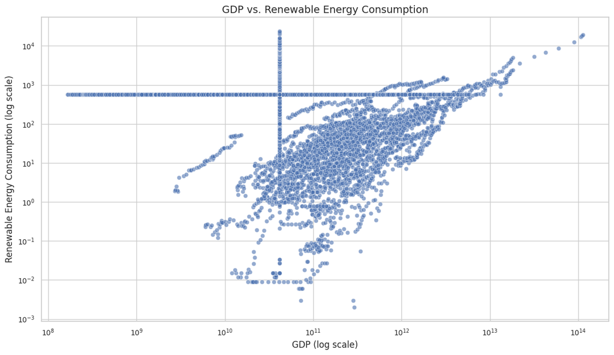

```python
plt.figure(figsize=(12, 7))
sns.set(style="whitegrid")

# Scatter plot for 'GDP' vs. 'Renewable Energy Consumption'
sns.scatterplot(data=df, x='gdp', y='renewables_consumption', alpha=0.6)

# Log scale for better visibility on wide range data
plt.xscale('log')
plt.yscale('log')

# Improve the readability of the tick labels
plt.xticks(fontsize=10)
plt.yticks(fontsize=10)

# Add labels and title with larger font sizes
plt.xlabel('GDP (log scale)', fontsize=12)
plt.ylabel('Renewable Energy Consumption (log scale)', fontsize=12)
plt.title('GDP vs. Renewable Energy Consumption', fontsize=14)

# Show the plot with a tight layout
plt.tight_layout()
plt.show()
```

The scatterplot suggests a positive correlation between GDP and renewable energy consumption. As GDP increases, the consumption of renewable energy appears to also increase. This is indicated by the upward trend of the data points in the scatterplot.The distribution of data points along the GDP axis seems to be right-skewed, with a long tail towards the higher end of the GDP scale. This tail represents a smaller number of countries with very high GDP. In concclusion, this supports the general notion that economic growth is associated with increased consumption of GDP.

# Population vs. Fossil Fuel Consumption

A bar chart can illustrate how fossil fuel consumption varies with population. This can show if more populous countries consume more fossil fuels.

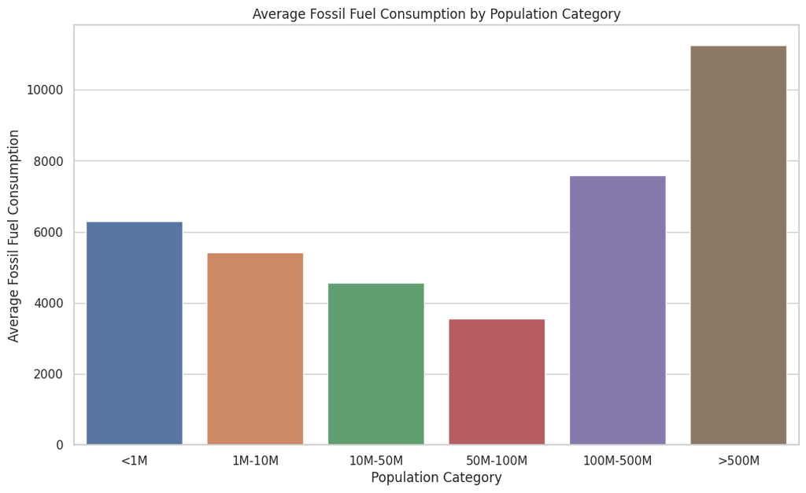

```python
# Define population bins. You might need to adjust these bins based on your data distribution.
population_bins = [0, 1000000, 10000000, 50000000, 100000000, 500000000, 1000000000]
bin_labels = ['<1M', '1M-10M', '10M-50M', '50M-100M', '100M-500M', '>500M']

# Bin population into categories
df['population_category'] = pd.cut(df['population'], bins=population_bins, labels=bin_labels)

# Calculate average fossil fuel consumption for each population category
average_consumption_by_pop = df.groupby('population_category')['fossil_fuel_consumption'].mean().reset_index()

plt.figure(figsize=(12, 7))
sns.set(style="whitegrid")

# Now, we can plot the average fossil fuel consumption for each population category
sns.barplot(x='population_category', y='fossil_fuel_consumption', data=average_consumption_by_pop)

plt.title('Average Fossil Fuel Consumption by Population Category')
plt.xlabel('Population Category')
plt.ylabel('Average Fossil Fuel Consumption')
plt.show()
```

# Total Energy Consumption over Time

A line chart can track changes in total energy consumption over years, revealing trends and fluctuations.

```python
print(df.columns)
```

```
Index(['country', 'year', 'iso_code', 'population', 'gdp',
       'biofuel_cons_change_pct', 'biofuel_cons_change_twh',
       'biofuel_cons_per_capita', 'biofuel_consumption',
       'biofuel_elec_per_capita',
       ...
       'wind_cons_change_pct', 'wind_cons_change_twh', 'wind_consumption',
       'wind_elec_per_capita', 'wind_electricity', 'wind_energy_per_capita',
       'wind_share_elec', 'wind_share_energy', 'gdp_filled',
       'population_category'],
      dtype='object', length=131)
```

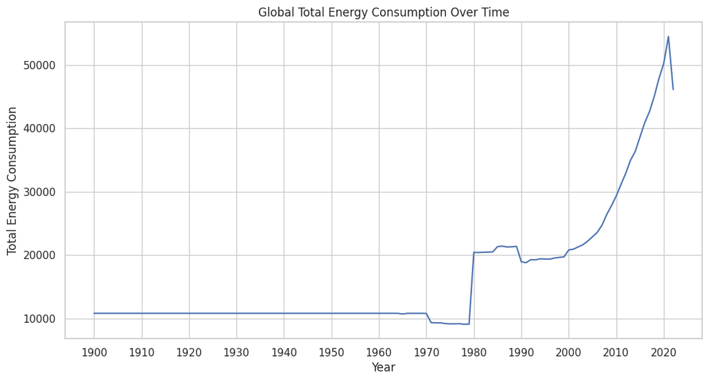

```python
import matplotlib.ticker as ticker
# List of energy consumption columns
energy_columns = ['biofuel_consumption', 'wind_consumption']  # Add other energy consumption columns here

# Sum up the energy consumption columns to create a total energy consumption column
# This assumes that all the listed columns are present in the DataFrame
if all(col in df.columns for col in energy_columns):
    df['total_energy_consumption'] = df[energy_columns].sum(axis=1)
else:
    missing_cols = [col for col in energy_columns if col not in df.columns]
    print(f"Missing columns in DataFrame: {missing_cols}")

# Aggregate total energy consumption by year
total_energy_per_year = df.groupby('year')['total_energy_consumption'].sum().reset_index()

# Plotting
plt.figure(figsize=(12, 6))
sns.lineplot(x='year', y='total_energy_consumption', data=total_energy_per_year)
plt.title('Global Total Energy Consumption Over Time')
plt.xlabel('Year')
plt.ylabel('Total Energy Consumption')

# Set x-axis ticks to every 10 years
plt.gca().xaxis.set_major_locator(ticker.MultipleLocator(10))
plt.show()
```